# RockEvalR

Maarten van Hoef

2026-02-27

### 1 RockEvalR

RockEvalR is an R-package developped by Maarten van Hoef to import and analyse raw data from the Rock-Eval 7S in R. https://github.com/maartenvanhoef/RockEvalR

The package include functions to import data in the .B00 format. It is currently not possible to perform data callibration, therefore the data need to be have been processed by the Geoworks software first.

All functions commence with RE_.

### 2 Example file

It is recommended to run the example file with your data to get used to the R-package. The steps are explained below.

#### 2.1 Getting help

The R-package includes documentation for all functions on both their use in R and also their relation to Rock-Eval data interpretation.

```r
# Access the package overview page like:
?RockEvalR

# An index of all functions and help pages by:
help(package=RockEvalR)

# Or a access a specific function's help page like:
?RE_Ccombined()
```

#### 2.2 Getting started

First raw Rock-Eval 7S data need to be imported. The data need to be in a folder containing only Rock-Eval raw data files. RE_read will distinguish .B00 and .B00~. The raw data can be plotted including the base-lines and the cursors separating different pools of decomposition products.

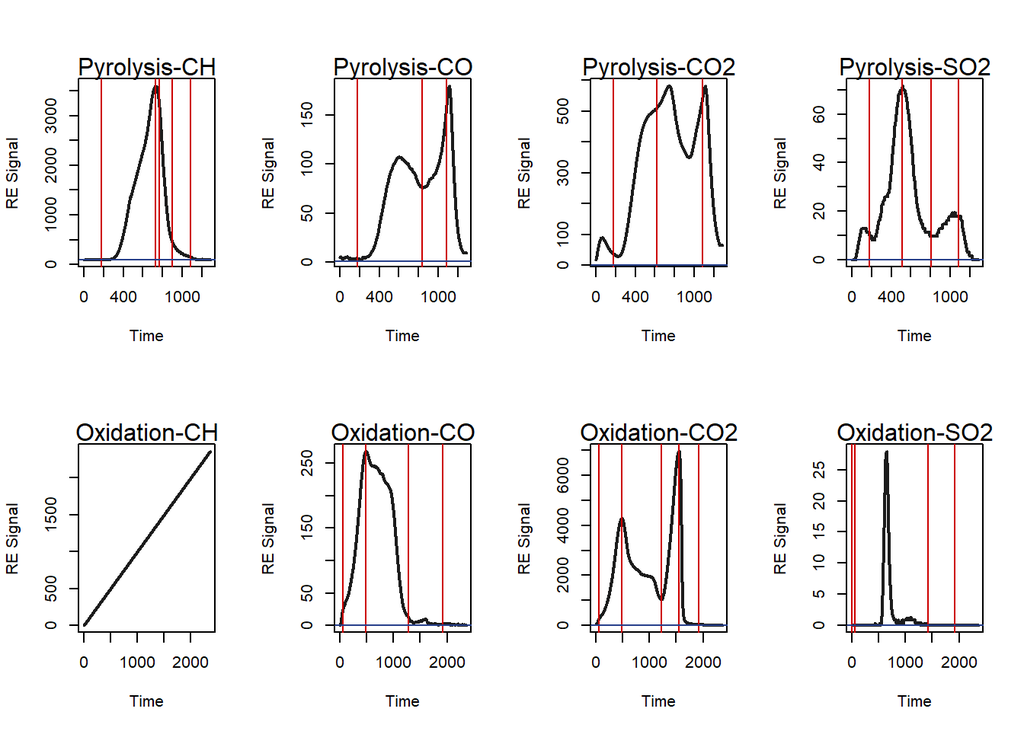

```r
# Load all data files in folder
REdata<-RE_read(datalocation)

# Plot first data file in read directory
RE_plot(REdata,1)
```

#### 2.3 Converting data

The raw signal data are not adjusted to the base-lines and the appropriate units. It is important to always convert the raw data to proper units before further calculations.

```r
# Convert raw RE data to values with proper units
REdata.adj<-RE_convert(REdata)
```

#### 2.4 Adjusting the separation between organic and inorganic CO2.

Based on experience with soil-like matrices we found the TOC-TIC determination was improved by adjusting the separation between the organic and inorganic part of the pyrolysed CO2. This is an optional step, and the relevance depends on the type of sample analysed. It is possible to plot the determination of the improved temperature for separation.

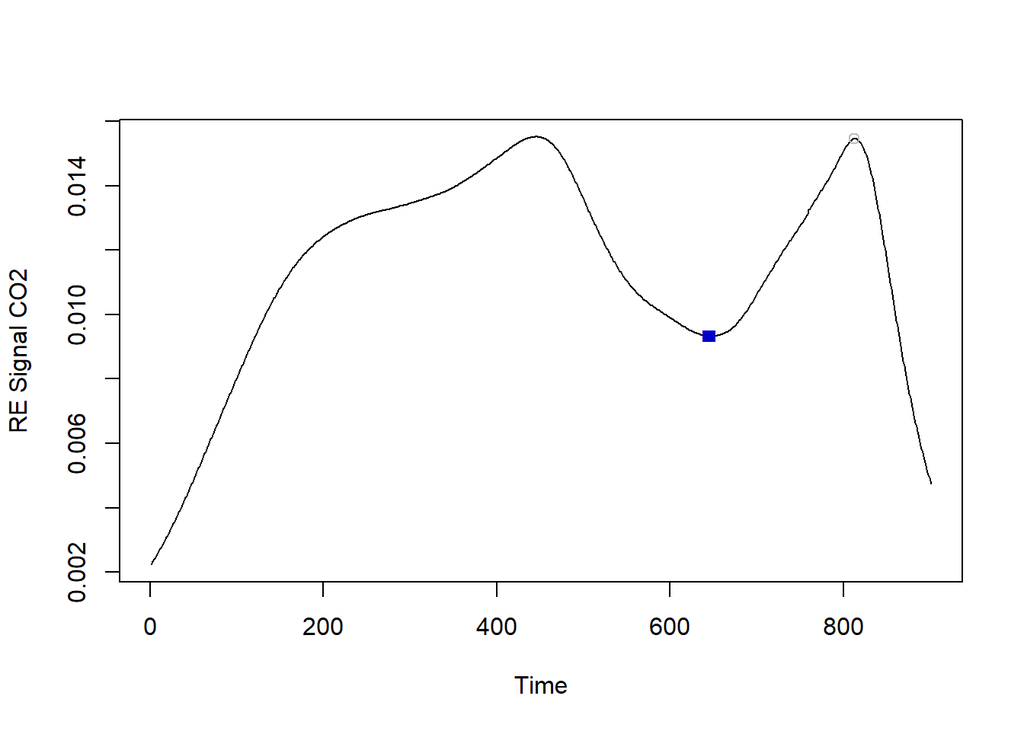

```r
# Adjust the pyrolysis CO2 cursor 2 to the valley between OC and IC peaks (only for SOIL and SOIL TS cycles)
REdata.adj<-RE_cursadjust(REdata.adj, plot = T)
```

#### 2.5 Calculating the standard Rock-Eval parameters.

After the data are converted to the right units the standard Rock-Eval parameters can be calculated. The surfaces S1, S2, etc. are derived from integration of the measurement curves. The TOC, OI, etc. are calculated by the formulation of the Rock-Eval interpretation. (Baudin, 2023. The Rock‐Eval Method: Principles and Application)

```r
# Calculate RE zones (S1, S2, ...)
REdata.adj<-RE_surfaces(REdata.adj)

# Compute the RE metrics (TOC, OI, ...)
REdata.adj<-RE_metrics(REdata.adj)
```

#### 2.6 Additional Rock-Eval computations in RockEvalR.

Additional calculations can be performed such as the I/R indices (Sebag 2016. Dynamics of soil organic matter based on new Rock-Eval indices).

```r
# Determine Sebag et al. (2016) parameters
REdata.adj<-RE_SebagIR(REdata.adj)

# Calculate T percentiles (i.e., T25, T50, and T75)
REdata.adj<-RE_Tpercentiles(REdata.adj)

# Standard percentiles are T25, T50 and T75 but any custom vector can be used as:
REdata.adj<-RE_Tpercentiles(REdata.adj, c(10,30,50,70,90))
```

#### 2.7 Sulphur computation

The Rock-Eval 7S also allows for analysis of decomposed Sulphur-species. The sulphur data need to be integrated separately in RockEvalR.

```r
#12.1 Compute surfaces
REdata.adj<-RE_Ssurfaces(REdata.adj)

#12.2 Derive metrics for S
REdata.adj<-RE_Smetrics(REdata.adj)

# The sulphur metrics often depend on empirical corrections so it is adviced to read the functions help page before use.
?RE_Smetrics()
```

#### 2.8 Advanced interpretation

The main benefit of RockEvalR is that data can be further analysed and integrated using non-standard approaches. All data are by default stored in flexibles nested lists and can be adapted freely. Section 3 provides an alphabetical overview of additional functions included in RockEvalR. However, the user is free to further manipulate the data according to their needs.

### 3 Functions included in RockEvalR

#### RE_calculateall

Combines all main functions in one go. Not recommended for first time use. RE_convert(), RE_surfaces(), RE_metrics(), RE_SebagIR(), and RE_Tpercentiles().

#### RE_Ccombined

Combines the amount of C released of the different thermograms to calculate the flux of PC and RC over time.

This function calculates the amount of released C at every time step (instead of integrating it over an entire period). The input needs to be data converted to the right units by using the function RE_convert().

#### RE_convert

This function derives the elemental amount using calibration, baseline and sample weight.

It is important to convert the thermogram data to the right units, before using most other functions. This function performs the conversion using the callibration values and baseline. The input data should be the list of raw data files which is read by the function RE_read(dataloc).

#### RE_cumtraparea

This function does a step wise trapezoidal integration.

#### RE_cursadjust

This function adjusts the unaltered pyrolysis CO2 cursor which separates organic and inorganic C. The function alters only the samples that are run with the SOIL or SOIL TS cycle and only samples that have their cursor not manually adjusted already.

A separation between organic and inorganic CO2 is made based on a temperature cut-off. By default this value is fixed at 400 C in Geoworks, however, for soils the valley between the two peaks may be more appropriate. Adjusting the temperature cut-off to the local minimum between the organic and inorganic peak may result in a more appropriate calculation of TOC and TIC.

#### RE_customarea

This function calculates the areas between a set of temperatures. Input should be converted already. The areas between all temperatures is given plus the area between t0 and the first temperature and the area after the highest temperature is reached. All output parameters have the same units as their fully integrated counterparts.

It is important that first the data have been converted to the right units (by calibration values) and that the baseline is set to 0. Converting the raw measurements to proper units and baselined values can be done with the RE_convert() function. This function integrates any thermograms. Integration happens between the temperatures that are given as a vector argument in the function. The lowest temperature and highest temperatures should not be included in the argument vector. So vector c(300,450,500) will result in the integration: T < 300, T 300-450, T 450-500, and T > 500.

#### RE_extracttable

Creates a table with all calculated metrics added to the data.

#### RE_metrics

This function calculates main Rock-Eval metrics from zone areas.

It is necessary that the RE surfaces have been integrated first. This can be done with the RE_surfaces() function. From these areas the basic Rock-Eval metrics are then computed.

- Tpeak, RE7 temperature at S2 peak (C)
- POC, pyrolysis organic C (%)
- ROC, residual organic C (%)
- TOC, total organic C (%)
- PIC, pyrolysis inorganic C (%)
- RIC, residual inorganic C (%)
- TIC, total inorganic C (%)
- HI, hydrogen index (mg CH/ g TOC)
- OI_CO, CO oxygen index (mg CO/ g TOC)
- OI_CO2, main oxygen index (mg CO2/ g TOC)
- OI_combi, combined oxygen index/ OIRE6 (mg O/ g TOC)

#### RE_OHcombined

Combines the amount of H and O released of the different thermograms to calculate their respective fluxes over time.

This function calculates the amount of released H and O at every time step (instead of integrating it over an entire period). The input needs to be data converted to the right units by using the function RE_convert(). The H and O released during pyrolysis originate from the sample, whereas the O released during oxidation also originates from the air in the oven.

#### RE_plot

This function previews Rock-Eval thermograms and cursors. Input contains a single Rock-Eval analysis.

#### RE_read

This function loads all Rock-Eval raw data files into a list.

Before using any function the raw Rock-Eval data need to be read into the right format. This format is a list that contains a list for each sample with all appropriate data.

This function will read all files in the indicated data location. It’s important only raw Rock-Eval data are stored in that location. The function will only use .B00 files, .B00~ files are ignored. If data are erroneously read this may result from parameters missing, parameters being in an unexpected location in the file, or from additional unexpected data being part of the file. This can usually be helped by reading the fresh raw data (e.g., the .B00~ file) into an updated version of Geoworks. Reading of data files after Geoworks conversion was last checked for version: V1.8R1.

#### RE_SebagIR

Calculates the areas A1, A2, A3, A4 plus the I and R indices. (Sebag, 2016. Dynamics of soil organic matter based on new Rock-Eval indices)

#### RE_Smetrics

It is necessary that the RE Sulphur surfaces have been integrated first. This can be done with the RE_Ssurfaces() function. Additionally, for the sulphur index (SI) the total C has to be determined with the RE_surfaces() function. From these areas the basic Rock-Eval metrics are then computed. The determination of most sulphur-species depends on empirical correction of matrix effects. Based on type of sample (e.g., Kerogen type), and data availability different empirical adjustments may lead to better results.

In this case total organic S is calculated from a relationship with the Tmax_CH during pyrolysis:

(Pyrolysed org S) / (Total org S) = (org.conversion.a) x (Tmax_CH) + (org.conversion.b)

(Total inorg S) = (Total S) - (Total org S)

- Tpeak_S, RE7 temperature at organic SO2 peak during pyrolysis (C)
- POS, pyrolysis organic S (%)
- PIS, pyrolysis inorganic S (%)
- RTS, total oxidised S (%)
- TS, total measured S (%)
- PyOS.emp, emperically determined ratio of pyrolysed organic S (%)
- ROS.cor, empirically corrected residual organic S (%)
- TOS.cor, empirically corrected total organic S (%)
- RIS.cor, empirically corrected residual inorganic S (%)
- TIS.cor, empirically corrected total inorganic S (%)
- SI, sulphur index (mg total org. S/ g TOC)
- SI.pyr, labile sulphur index (mg pyrolysed org. S/ g TOC)

#### RE_Ssurfaces

This function calculates the areas of the different Rock-Eval zones for Sulphur. Input should be converted already. As an option the zones can also be included as a time series. It is important that first the data have been converted to the right units (by calibration values) and that the baseline is set to 0. Converting the raw measurements to proper units and baselined values can be done with the RE_convert() function. This function integrates the different thermograms for S. Integration happens between the cursors that were determined automatically or manually adjusted. Here the areas and nomenclature of Cohen-Sadon et al. (2022) are used instead of those in Geoworks. However, the cut-off temperatures are not fixed an based on the cursors and local minima.

- S1S, pyrolysed before start of the heating ramp
- S2S, pyrolysed from start of heating until minimum between 400 and 550 C
- S3S, pyrolysed after minimum between 400 and 550 C
- S4S, oxidised below minimum between 550 and 650 C
- S5S, oxidised above minimum between 550 and 650 C

#### RE_surfaces

This function calculates the areas of the different Rock-Eval zones. Input should be converted already. As an option the zones can also be included as a time series.

It is important that first the data have been converted to the right units (by calibration values) and that the baseline is set to 0. Converting the raw measurements to proper units and baselined values can be done with the RE_convert() function. This function integrates the different thermograms for C. Integration happens between the cursors that were determined automatically or manually adjusted. The cursors are normally determined by Geoworks. Manual adjustment of the S3 organic-inorganic separation for the soil program can be done with the RE_cursadjust() function.

- S1, Free hydrocarbons (mg HC/g)
- S2, Pyrolysable hydrocarbons (mg HC/g)
- S3CO, Pyrolysable organic CO (mg CO/g)
- SS3COi, Pyrolysable inorganic CO (mg CO/g)
- SS3CO2, Pyrolysable organic CO2 (mg CO2/g)
- SS3CO2i, Pyrolysable organic CO2 (mg CO2/g)
- SS4CO, Oxidised organic CO (mg CO/g)
- SS4COi, Oxidised inorganic CO (mg CO/g)
- SS4CO2, Oxidised organic CO2 (mg CO2/g)
- SS5, Oxidised inorganic CO2 (mg CO2/g)

#### RE_Tpercentiles

Calculates the temperature percentiles of the thermograms.

#### RE_traparea

This function does a simplified trapezoidal integration.